# Milan Urban Mobility Survey – Cluster Analysis

## Grouped Bar Chart: Transport Mode Usage by Cluster

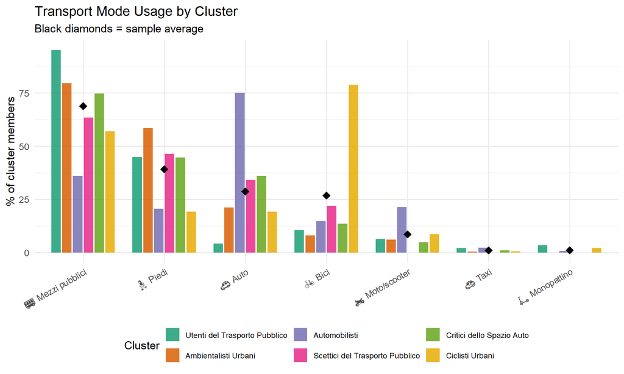

```r
transport_modes <- c("auto", "bici", "mezzi_pub", "piedi", "moto_scooter", "taxi", "monopattino")

transport_labels <- c(
  "auto" = "\U0001F697 Auto", "bici" = "\U0001F6B2 Bici",
  "mezzi_pub" = "\U0001F68C Mezzi pubblici", "piedi" = "\U0001F6B6 Piedi",
  "moto_scooter" = "\U0001F3CD Moto/scooter",
  "taxi" = "\U0001F695 Taxi", "monopattino" = "\U0001F6F4 Monopattino"
)

transport_data <- df_complete |>
  group_by(cluster_final) |>
  summarise(
    across(all_of(transport_modes), ~ mean(. == "Yes") * 100),
    n = n(),
    .groups = "drop"
  ) |>
  pivot_longer(all_of(transport_modes), names_to = "mode", values_to = "pct") |>
  mutate(mode_label = transport_labels[mode],
         mode_label = fct_reorder(mode_label, -pct))

# Sample average for reference
transport_avg <- df_complete |>
  summarise(across(all_of(transport_modes), ~ mean(. == "Yes") * 100)) |>
  pivot_longer(everything(), names_to = "mode", values_to = "pct_avg") |>
  mutate(mode_label = transport_labels[mode])

ggplot(transport_data, aes(x = mode_label, y = pct, fill = cluster_final)) +
  geom_col(position = position_dodge(width = 0.8), width = 0.7, alpha = 0.85) +
  geom_point(data = transport_avg, aes(x = mode_label, y = pct_avg),
             inherit.aes = FALSE, shape = 18, size = 4, color = "black") +
  scale_fill_clusters() +
  labs(
    title = "Transport Mode Usage by Cluster",
    subtitle = "Black diamonds = sample average",
    x = NULL, y = "% of cluster members", fill = "Cluster"
  ) +
  theme(
    axis.text.x = element_text(angle = 30, hjust = 1),
    legend.position = "bottom",
    legend.text = element_text(size = 9)
  )
```

## Grouped Bar Chart: Attitude Toward Limiting Cars

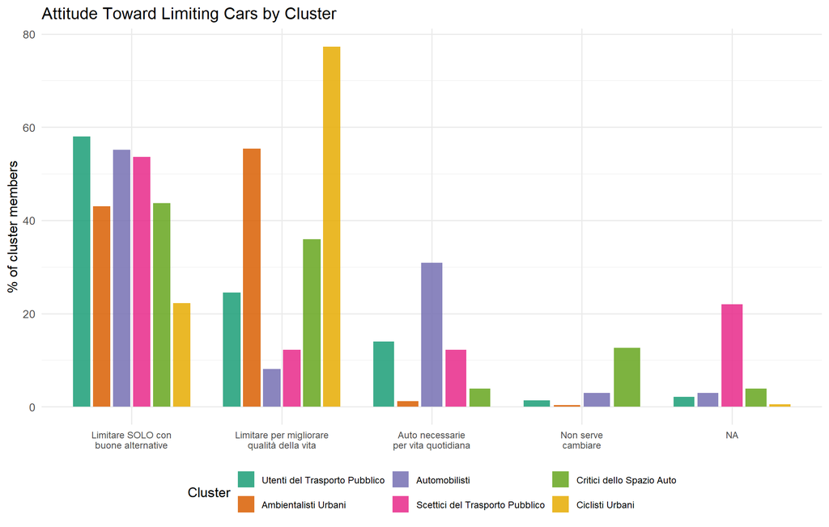

```r
# Shorter labels for the limitare_auto categories
limitare_short <- c(
  "Limiterei le auto per migliorare la qualità della vita in città" = "Limitare per migliorare\nqualità della vita",
  "Limiterei le auto SOLO se ci fossero buone alternative per muoversi" = "Limitare SOLO con\nbuone alternative",
  "Trovo che le auto siano necessarie per la vita quotidiana" = "Auto necessarie\nper vita quotidiana",
  "Non sento il bisogno di cambiare la situazione attuale" = "Non serve\ncambiare",
  "Non ho un'opinione precisa a riguardo" = "Nessuna opinione\nprecisa"
)

limitare_data <- df_complete |>
  dplyr::count(cluster_final, limitare_auto) |>
  group_by(cluster_final) |>
  mutate(pct = n / sum(n) * 100) |>
  ungroup() |>
  mutate(
    limitare_short = limitare_short[as.character(limitare_auto)],
    limitare_short = fct_reorder(limitare_short, -pct)
  )

ggplot(limitare_data, aes(x = limitare_short, y = pct, fill = cluster_final)) +
  geom_col(position = position_dodge(width = 0.8), width = 0.7, alpha = 0.85) +
  scale_fill_clusters() +
  labs(
    title = "Attitude Toward Limiting Cars by Cluster",
    x = NULL, y = "% of cluster members", fill = "Cluster"
  ) +
  theme(
    axis.text.x = element_text(size = 9),
    legend.position = "bottom",
    legend.text = element_text(size = 9)
  )
```

# Dimensionality Reduction Visualizations

The cluster profiles tell us *what* distinguishes each group, but not how clearly separated they are in the data. Dimensionality reduction visualizations project the high-dimensional respondent data into two dimensions for visual inspection. If clusters appear as distinct clouds, the separation is strong; if they overlap heavily, the clusters represent tendencies rather than sharp boundaries. Both outcomes are informative for understanding citizen attitudes.

## t-SNE on Gower Distance

**t-SNE (t-distributed Stochastic Neighbor Embedding)** is a nonlinear dimensionality reduction technique that excels at preserving local neighborhoods: respondents who are similar in the full 25-variable space will appear close together in the 2D plot. Unlike PCA, t-SNE can reveal non-convex cluster shapes. We run it directly on the Gower distance matrix.

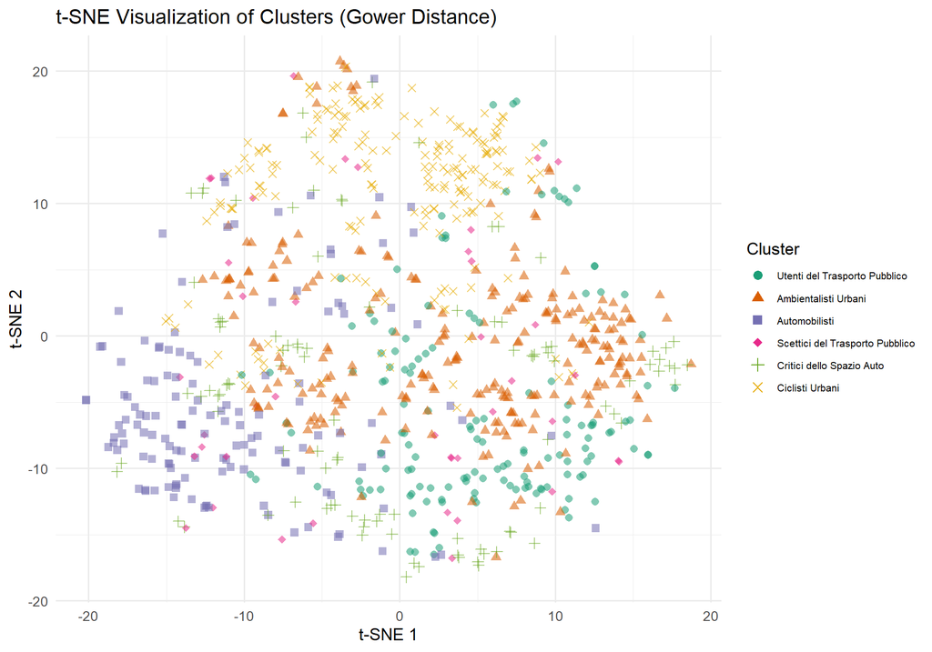

```r
tsne_result <- Rtsne(gower_dist, is_distance = TRUE, perplexity = 30, dims = 2)

tsne_df <- tibble(
  tSNE1 = tsne_result$Y[, 1],
  tSNE2 = tsne_result$Y[, 2],
  Cluster = df_complete$cluster_final
)

ggplot(tsne_df, aes(tSNE1, tSNE2, color = Cluster, shape = Cluster)) +
  geom_point(alpha = 0.55, size = 2.5) +
  scale_color_clusters(name = "Cluster") +
  scale_shape_manual(name = "Cluster",
                     values = c(16, 17, 15, 18, 3, 4, 8, 1, 2)[seq_len(n_clusters)]) +
  labs(title = "t-SNE Visualization of Clusters (Gower Distance)",
       x = "t-SNE 1", y = "t-SNE 2") +
  guides(color = guide_legend(override.aes = list(size = 3, alpha = 1))) +
  theme(legend.position = "right",
        legend.text = element_text(size = 8))
```

## FAMD Biplot Colored by Cluster

The FAMD biplot shows respondents positioned on the first two factor dimensions (the same ones from Method 2). Unlike t-SNE, the axes are interpretable – they correspond to the variable contributions shown earlier. The percentage of variance explained by each axis indicates how much of the total data variation is captured in this 2D view.

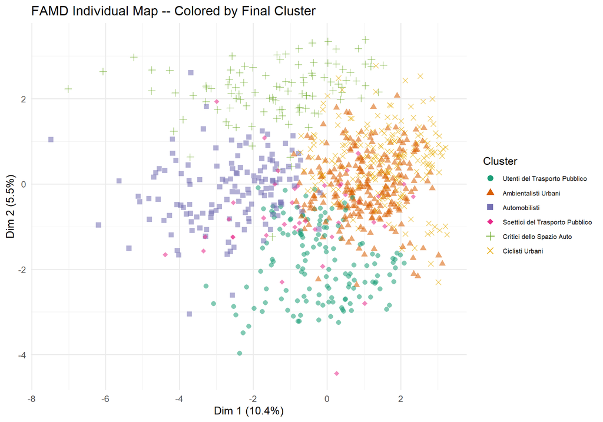

```r
famd_df <- tibble(
  Dim1 = famd_result$ind$coord[, 1],
  Dim2 = famd_result$ind$coord[, 2],
  Cluster = df_complete$cluster_final
)

ggplot(famd_df, aes(Dim1, Dim2, color = Cluster, shape = Cluster)) +
  geom_point(alpha = 0.55, size = 2.5) +
  scale_color_clusters(name = "Cluster") +
  scale_shape_manual(name = "Cluster",
                     values = c(16, 17, 15, 18, 3, 4, 8, 1, 2)[seq_len(n_clusters)]) +
  labs(title = "FAMD Individual Map -- Colored by Final Cluster",
       x = paste0("Dim 1 (", round(famd_result$eig[1, 2], 1), "%)"),
       y = paste0("Dim 2 (", round(famd_result$eig[2, 2], 1), "%)")) +
  guides(color = guide_legend(override.aes = list(size = 3, alpha = 1))) +
  theme(legend.text = element_text(size = 8))
```

## PAM Medoids (Representative Individuals)

The medoid is the most centrally located member of each PAM cluster – the respondent whose overall profile is closest to all other members of their group. Examining medoids gives us a concrete, real-person embodiment of each persona.

```r
medoid_indices <- pam_fit$id.med
df_complete |>
  slice(medoid_indices) |>
  select(cluster_pam, all_of(names(df_clust))) |>
  knitr::kable(caption = "PAM Medoids -- Representative Individuals per Cluster")
```

PAM Medoids – Representative Individuals per Cluster

| cluster_pam | spazio_auto | trasp_pub_ineff | meno_auto_clima | normale_auto | piu_verde | aggreg_disturbo | parcheggi_aggreg | eta | dist_duomo_km | prio_circolazione | prio_mobilita_sost | prio_parcheggi | prio_verde_urbano | prio_cultura_sport | prio_socialita | auto | bici | mezzi_pub | piedi | moto_scooter | taxi | monopattino | limitare_auto | lavoro | genere |
| --- | --- | --- | --- | --- | --- | --- | --- | --- | --- | --- | --- | --- | --- | --- | --- | --- | --- | --- | --- | --- | --- | --- | --- | --- | --- |
| 1 | 7 | 4 | 8 | 5 | 5 | 6 | 4 | 40 | 4.901942 | 2 | 0 | 3 | 1 | 0 | 0 | Yes | No | No | No | No | No | No | Trovo che le auto siano necessarie per la vita quotidiana | Lavoratore dipendente | Femminile |
| 2 | 9 | 6 | 6 | 2 | 7 | 4 | 6 | 32 | 6.152902 | 0 | 2 | 0 | 3 | 0 | 1 | No | No | Yes | No | No | No | No | Limiterei le auto SOLO se ci fossero buone alternative per muoversi | Lavoratore dipendente | Femminile |
| 3 | 10 | 3 | 10 | 1 | 10 | 1 | 10 | 38 | 3.514234 | 0 | 3 | 0 | 2 | 1 | 0 | No | Yes | Yes | No | No | No | No | Limiterei le auto per migliorare la qualità della vita in città | Lavoratore dipendente | Maschile |
| 4 | 7 | 6 | 8 | 3 | 8 | 3 | 6 | 34 | 4.408993 | 0 | 0 | 0 | 2 | 1 | 3 | Yes | No | Yes | No | No | No | No | Limiterei le auto SOLO se ci fossero buone alternative per muoversi | Lavoratore dipendente | Maschile |
| 5 | 10 | 3 | 10 | 1 | 10 | 3 | 8 | 37 | 4.408993 | 0 | 2 | 0 | 3 | 1 | 0 | No | No | Yes | Yes | No | No | No | Limiterei le auto per migliorare la qualità della vita in città | Lavoratore dipendente | Femminile |
| 6 | 8 | 3 | 8 | 1 | 7 | 4 | 7 | 26 | 2.383858 | 0 | 0 | 0 | 3 | 2 | 1 | No | No | Yes | Yes | No | No | No | Limiterei le auto per migliorare la qualità della vita in città | Lavoratore dipendente | Maschile |

# Cluster Interpretation

The 6 clusters identified by the analysis represent distinct citizen archetypes with coherent attitudes toward urban mobility, environmental priorities, and car usage in Milan. The labels are assigned programmatically based on each cluster’s most distinctive feature (see table above), so they remain correct across re-runs. Each persona profile below is generated dynamically from the data.

```r
limit_solo <- "Limiterei le auto SOLO se ci fossero buone alternative per muoversi"
limit_yes  <- "Limiterei le auto per migliorare la qualità della vita in città"
limit_need <- "Trovo che le auto siano necessarie per la vita quotidiana"

transport_mode_labels <- c(
  auto = "car", bici = "bicycle", mezzi_pub = "public transit",
  piedi = "walking", moto_scooter = "moto/scooter"
)

for (cl in levels(df_complete$cluster_final)) {
  d <- df_complete |> filter(cluster_final == cl)
  cl_name <- cl
  n_cl <- nrow(d)
  pct_sample <- round(n_cl / nrow(df_complete) * 100, 1)

  # Dominant transport mode
  mode_pcts <- sapply(names(transport_mode_labels), function(m) mean(d[[m]] == "Yes"))
  top_mode <- names(which.max(mode_pcts))
  top_mode_pct <- round(max(mode_pcts) * 100)
  car_pct <- round(mean(d$auto == "Yes") * 100)

  # Attitudes
  m_spazio   <- round(mean(d$spazio_auto), 1)
  m_clima    <- round(mean(d$meno_auto_clima), 1)
  m_normale  <- round(mean(d$normale_auto), 1)
  m_trasp    <- round(mean(d$trasp_pub_ineff), 1)
  m_parcheg  <- round(mean(d$parcheggi_aggreg), 1)
  m_verde    <- round(mean(d$piu_verde), 1)

  # Car-limiting
  p_limit_yes  <- round(mean(d$limitare_auto == limit_yes) * 100)
  p_limit_solo <- round(mean(d$limitare_auto == limit_solo) * 100)
  p_limit_need <- round(mean(d$limitare_auto == limit_need) * 100)

  # Demographics
  m_eta <- round(mean(d$eta), 1)
  top_lavoro <- d |> dplyr::count(lavoro, sort = TRUE) |> slice(1)
  top_lav_pct <- round(top_lavoro$n / n_cl * 100)

  cat("\n## \"", cl_name, "\"\n\n", sep = "")

  cat("**", n_cl, " members (", pct_sample, "% of sample).** ",
      "Dominant transport: ", transport_mode_labels[top_mode],
      " (", top_mode_pct, "%)",
      if (top_mode != "auto") paste0("; car usage ", car_pct, "%") else "",
      ". Mean age: ", m_eta, ". ",
      "Largest employment group: ", as.character(top_lavoro$lavoro),
      " (", top_lav_pct, "%).\n\n", sep = "")

  cat("**Attitudes** (1-10 scale): ",
      "too much space for cars = ", m_spazio,
      ", fewer cars for climate = ", m_clima,
      ", normal to have cars = ", m_normale,
      ", public transport inefficient = ", m_trasp,
      ", more green space = ", m_verde,
      ", parking to social spaces = ", m_parcheg, ".\n\n", sep = "")

  cat("**Car-limiting policy**: ",
      p_limit_yes, "% would limit unconditionally, ",
      p_limit_solo, "% only with alternatives, ",
      p_limit_need, "% consider cars necessary.\n\n", sep = "")
}
```

## “Utenti del Trasporto Pubblico”

**143 members (16.4% of sample).** Dominant transport: public transit (95%); car usage 4%. Mean age: 26.1. Largest employment group: Studente (59%).

**Attitudes** (1-10 scale): too much space for cars = 7, fewer cars for climate = 7.3, normal to have cars = 3.7, public transport inefficient = 5, more green space = 7.3, parking to social spaces = 5.8.

**Car-limiting policy**: 24% would limit unconditionally, 58% only with alternatives, 14% consider cars necessary.

## “Ambientalisti Urbani”

**251 members (28.8% of sample).** Dominant transport: public transit (80%); car usage 21%. Mean age: 42.5. Largest employment group: Lavoratore dipendente (65%).

**Attitudes** (1-10 scale): too much space for cars = 8.9, fewer cars for climate = 8.5, normal to have cars = 2, public transport inefficient = 4.8, more green space = 8.8, parking to social spaces = 7.2.

**Car-limiting policy**: 55% would limit unconditionally, 43% only with alternatives, 1% consider cars necessary.

## “Automobilisti”

**136 members (15.6% of sample).** Dominant transport: car (75%). Mean age: 44.8. Largest employment group: Lavoratore dipendente (52%).

**Attitudes** (1-10 scale): too much space for cars = 6, fewer cars for climate = 5.4, normal to have cars = 3.6, public transport inefficient = 5.2, more green space = 5.6, parking to social spaces = 3.8.

**Car-limiting policy**: 8% would limit unconditionally, 55% only with alternatives, 31% consider cars necessary.

## “Scettici del Trasporto Pubblico”

**41 members (4.7% of sample).** Dominant transport: public transit (63%); car usage 34%. Mean age: 39.5. Largest employment group: In cerca di occupazione (61%).

**Attitudes** (1-10 scale): too much space for cars = 7.8, fewer cars for climate = 7.2, normal to have cars = 2.8, public transport inefficient = 6.1, more green space = 7.2, parking to social spaces = 7.1.

**Car-limiting policy**: 12% would limit unconditionally, 54% only with alternatives, 12% consider cars necessary.

## “Critici dello Spazio Auto”

**103 members (11.8% of sample).** Dominant transport: public transit (75%); car usage 36%. Mean age: 72.4. Largest employment group: Pensionato (92%).

**Attitudes** (1-10 scale): too much space for cars = 7.7, fewer cars for climate = 7.1, normal to have cars = 2.5, public transport inefficient = 4.3, more green space = 6.3, parking to social spaces = 4.8.

**Car-limiting policy**: 36% would limit unconditionally, 44% only with alternatives, 4% consider cars necessary.

## “Ciclisti Urbani”

**198 members (22.7% of sample).** Dominant transport: bicycle (79%); car usage 19%. Mean age: 40.8. Largest employment group: Lavoratore dipendente (68%).

**Attitudes** (1-10 scale): too much space for cars = 9.1, fewer cars for climate = 8, normal to have cars = 1.8, public transport inefficient = 4.3, more green space = 8.9, parking to social spaces = 7.8.

**Car-limiting policy**: 77% would limit unconditionally, 22% only with alternatives, 0% consider cars necessary.